```python
%matplotlib inline
import matplotlib.pyplot as plt
import pandas as pd
import numpy as np
import seaborn as sns

from sklearn.datasets import fetch_california_housing
from sklearn.linear_model import LinearRegression
from sklearn.preprocessing import StandardScaler
from sklearn.pipeline import Pipeline
from sklearn.model_selection import train_test_split
from sklearn.metrics import mean_squared_error
from sklearn.preprocessing import PolynomialFeatures
from sklearn.pipeline import Pipeline
from sklearn.model_selection import GridSearchCV
from sklearn.preprocessing import PowerTransformer
```

# College Graduation Rates

## Description

Data includes college data including teacher/pupil ratio and graduation rates  
Target = graduation rates

### Exploration and descriptive analysis

- Are there missing values?
- Any feature encoding?
- Any feature engineering?

### Feature selection

- correlation
- sklearn
- feature selection

### Model 1

- LinearRegression

### Model 2

- LinearRegression with PolynomialFeatures

### Model 3

- Grid Search CV with Pipeline

### Model 4

- Get dummies on the "Is_Private" data and extrapolate

### Summary

- Using a LinearRegression and "Out-of-state tuition", Root Mean Squared Error is 30.557800507931997
- Using a LinearRegression and "Top10perc" (Pct. new students from top 10% of H.S. class), "Top25perc" (Pct. new students from top 25% of H.S. class) and "perc.alumni" (Pct. alumni who donate), Root Mean Squared Error is **13.957955215160267**
- Using Train-Test-Split and Grid Search CV with 'Out-of-state Tuition' & 'Pct. new students from top 10% of H.S. class', RMSE is **11.651145402202511**
- Using a Power Transformer with 'Out-of-state Tuition' & 'Pct. new students from top 10% of H.S. class', RMSE is 13.556374491316712
- Using a LinearRegression with the 'Yes_Private' data, RMSE is 16.167623244714516
- Same result using a GridSearchCV with the same data

```python
college_data = pd.read_csv("College_Data.csv")
college_data.head()
```

|  | Unnamed: 0 | Private | Apps | Accept | Enroll | Top10perc | Top25perc | F.Undergrad | P.Undergrad | Outstate | Room.Board | Books | Personal | PhD | Terminal | S.F.Ratio | perc.alumni | Expend | Grad.Rate |
| --- | --- | --- | --- | --- | --- | --- | --- | --- | --- | --- | --- | --- | --- | --- | --- | --- | --- | --- | --- |
| 0 | Abilene Christian University | Yes | 1660 | 1232 | 721 | 23 | 52 | 2885 | 537 | 7440 | 3300 | 450 | 2200 | 70 | 78 | 18.1 | 12 | 7041 | 60 |
| 1 | Adelphi University | Yes | 2186 | 1924 | 512 | 16 | 29 | 2683 | 1227 | 12280 | 6450 | 750 | 1500 | 29 | 30 | 12.2 | 16 | 10527 | 56 |
| 2 | Adrian College | Yes | 1428 | 1097 | 336 | 22 | 50 | 1036 | 99 | 11250 | 3750 | 400 | 1165 | 53 | 66 | 12.9 | 30 | 8735 | 54 |
| 3 | Agnes Scott College | Yes | 417 | 349 | 137 | 60 | 89 | 510 | 63 | 12960 | 5450 | 450 | 875 | 92 | 97 | 7.7 | 37 | 19016 | 59 |
| 4 | Alaska Pacific University | Yes | 193 | 146 | 55 | 16 | 44 | 249 | 869 | 7560 | 4120 | 800 | 1500 | 76 | 72 | 11.9 | 2 | 10922 | 15 |

[output not shown]

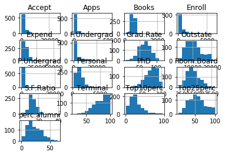

```python
college_data.hist()
```

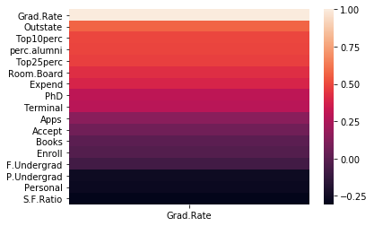

```python
#find features to base predictions on through correlation
sns.heatmap(college_data.corr()[['Grad.Rate']].sort_values(by='Grad.Rate', ascending=False))
```

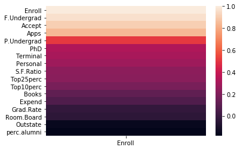

```python
sns.heatmap(college_data.corr()[['Enroll']].sort_values(by='Enroll', ascending=False))
```

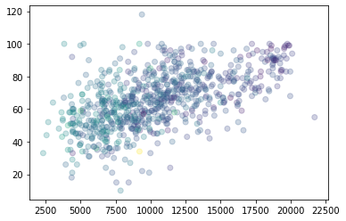

```python
plt.scatter(college_data['Outstate'], college_data['Grad.Rate'], c=college_data['S.F.Ratio'], alpha=.25)
```

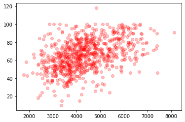

```python
plt.scatter(college_data['Room.Board'], college_data['Grad.Rate'], color='red', alpha=.25)
```

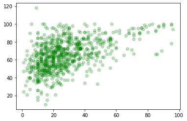

```python
plt.scatter(college_data['Top10perc'], college_data['Grad.Rate'], color='green', alpha=.25)
```

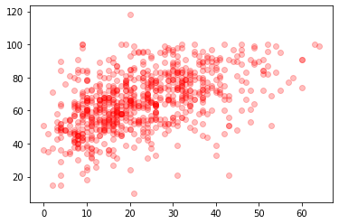

```python
plt.scatter(college_data['perc.alumni'], college_data['Grad.Rate'], color='red', alpha=.25)
```

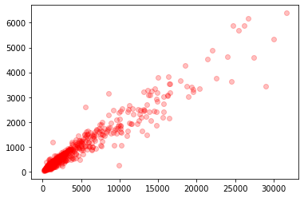

```python
plt.scatter(college_data['F.Undergrad'], college_data['Enroll'], color='red', alpha=.25)
```

```python
lr = LinearRegression()
```

```python
lr.fit(college_data[['Outstate']], college_data['Grad.Rate'])
```

```
LinearRegression(copy_X=True, fit_intercept=True, n_jobs=None, normalize=False)
```

```python
grad_preds = lr.predict(college_data[['Grad.Rate']])
```

```python
mean_squared_error(college_data['Grad.Rate'], grad_preds)
```

```
933.779171882569
```

```python
np.sqrt(mean_squared_error(college_data['Grad.Rate'], grad_preds))
```

```
30.557800507931997
```

```python
lr.intercept_
```

```
39.995114285087
```

```python
lr.coef_
```

```
array([0.00243933])
```

```python
lr.predict([[49062]])
```

```
array([159.67337463])
```

```python
lr2 = LinearRegression()
```

```python
lr2.fit(college_data[['Top10perc', 'Top25perc', 'perc.alumni']], college_data['Grad.Rate'])
grad_preds2 = lr2.predict(college_data[['Top10perc', 'Top25perc', 'perc.alumni']])
mse2 = mean_squared_error(college_data['Grad.Rate'], grad_preds2)
print(mse2)
rmse = np.sqrt(mse2)
print(rmse)
```

```
194.82451378841967
13.957955215160267
```

```python
lr2.coef_
```

```
array([0.19885688, 0.13541523, 0.46111443])
```

```python
lr2.intercept_
```

```
41.93986011376114
```

```python
X_train, X_test, y_train, y_test = train_test_split(college_data[['Outstate', 'Top10perc']], college_data['Grad.Rate'], random_state=42)
```

```python
#instantiate
lr3 = LinearRegression()

#fit
lr3.fit(X_train, y_train)

#predict
preds3 = lr3.predict(X_test)

#evaluate
mse = mean_squared_error(y_test, preds3)
print('MSE: ', mse)
rmse = np.sqrt(mse)
print('RMSE: ', rmse)
```

```
MSE:  135.7491891832648
RMSE:  11.651145402202514
```

```python
lr3.predict([[49062, 30]])
```

```
array([131.85241737])
```

```python
#Using Grid Search CV

#params
params = {'poly__degree':[1, 2, 3], 'lr__fit_intercept':[True, False]}

#pipe
pipe = Pipeline([('poly', PolynomialFeatures()), ('lr', LinearRegression())])

#grid
grid = GridSearchCV(pipe, param_grid=params)
```

```python
grid.fit(X_train, y_train)

preds4 = grid.predict(X_test)

mse4 = mean_squared_error(y_test, preds4)
rmse4 = np.sqrt(mse4)
print('RMSE: ', rmse4)
```

```
RMSE:  11.651145402202511
```

```python
grid.best_estimator_
```

```
Pipeline(memory=None,
         steps=[('poly',
                 PolynomialFeatures(degree=1, include_bias=True,
                                    interaction_only=False, order='C')),
                ('lr',
                 LinearRegression(copy_X=True, fit_intercept=True, n_jobs=None,
                                  normalize=False))],
         verbose=False)
```

```python
#Using a Power Transformer
pipe = Pipeline([('gauss', PowerTransformer()), ('lr', LinearRegression())])

#fit
pipe.fit(college_data[['Top10perc', 'Outstate']], college_data['Grad.Rate'])

#predict
powerpreds = pipe.predict(college_data[['Top10perc', 'Outstate']])
```

```python
powermse = mean_squared_error(college_data['Grad.Rate'], powerpreds)
print("MSE: ", powermse)
powerrmse = np.sqrt(powermse)
print("RMSE: ", powerrmse)
```

```
MSE:  183.7752893488224
RMSE:  13.556374491316712
```

```python
#how to change strings to numerical values
new_df = pd.get_dummies(college_data, columns=['Private'], drop_first=True)
```

```python
new_df.head()
```

|  | Unnamed: 0 | Apps | Accept | Enroll | Top10perc | Top25perc | F.Undergrad | P.Undergrad | Outstate | Room.Board | Books | Personal | PhD | Terminal | S.F.Ratio | perc.alumni | Expend | Grad.Rate | Private_Yes |
| --- | --- | --- | --- | --- | --- | --- | --- | --- | --- | --- | --- | --- | --- | --- | --- | --- | --- | --- | --- |
| 0 | Abilene Christian University | 1660 | 1232 | 721 | 23 | 52 | 2885 | 537 | 7440 | 3300 | 450 | 2200 | 70 | 78 | 18.1 | 12 | 7041 | 60 | 1 |
| 1 | Adelphi University | 2186 | 1924 | 512 | 16 | 29 | 2683 | 1227 | 12280 | 6450 | 750 | 1500 | 29 | 30 | 12.2 | 16 | 10527 | 56 | 1 |
| 2 | Adrian College | 1428 | 1097 | 336 | 22 | 50 | 1036 | 99 | 11250 | 3750 | 400 | 1165 | 53 | 66 | 12.9 | 30 | 8735 | 54 | 1 |
| 3 | Agnes Scott College | 417 | 349 | 137 | 60 | 89 | 510 | 63 | 12960 | 5450 | 450 | 875 | 92 | 97 | 7.7 | 37 | 19016 | 59 | 1 |
| 4 | Alaska Pacific University | 193 | 146 | 55 | 16 | 44 | 249 | 869 | 7560 | 4120 | 800 | 1500 | 76 | 72 | 11.9 | 2 | 10922 | 15 | 1 |

```python
new_X = new_df[['Private_Yes']]
new_y = new_df['Grad.Rate']
```

```python
new_lr = LinearRegression()
new_lr.fit(new_X, new_y)
```

```
LinearRegression(copy_X=True, fit_intercept=True, n_jobs=None, normalize=False)
```

```python
new_preds = new_lr.predict(new_X)
new_mse = mean_squared_error(new_y, new_preds)
print(new_mse)
new_rmse = np.sqrt(new_mse)
print(new_rmse)
```

```
261.3920413830332
16.167623244714516
```

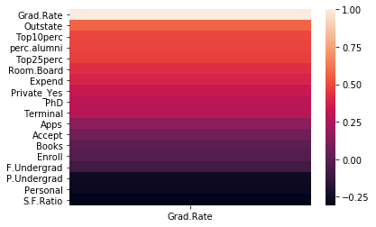

```python
#find features to base predictions on through correlation
sns.heatmap(new_df.corr()[['Grad.Rate']].sort_values(by='Grad.Rate', ascending=False))
```

### looks like 'yes_private' has a slight correlation but not too much

```python
#using grid search cv with "yes_private"
new_pipe = Pipeline([('poly', PolynomialFeatures()), ('lr', LinearRegression())])
params = {'poly__degree':[1, 2, 3, 4], 'lr__fit_intercept':[True, False]}
new_grid = GridSearchCV(new_pipe, param_grid=params, cv=5)
```

```python
new_grid.fit(new_X, new_y)
```

```
GridSearchCV(cv=5, error_score='raise-deprecating',
             estimator=Pipeline(memory=None,
                                steps=[('poly',
                                        PolynomialFeatures(degree=2,
                                                           include_bias=True,
                                                           interaction_only=False,
                                                           order='C')),
                                       ('lr',
                                        LinearRegression(copy_X=True,
                                                         fit_intercept=True,
                                                         n_jobs=None,
                                                         normalize=False))],
                                verbose=False),
             iid='warn', n_jobs=None,
             param_grid={'lr__fit_intercept': [True, False],
                         'poly__degree': [1, 2, 3, 4]},
             pre_dispatch='2*n_jobs', refit=True, return_train_score=False,
             scoring=None, verbose=0)
```

```python
newer_preds = new_grid.predict(new_X)
```

```python
newer_mse = mean_squared_error(new_y, newer_preds)
print(newer_mse)
newer_rmse = np.sqrt(newer_mse)
print(newer_rmse)
```

```
261.39204138303324
16.16762324471452
```

```python
#using grid search cv with "yes_private"
newest_X = new_df[['Private_Yes', 'Outstate']]
newest_pipe = Pipeline([('poly', PolynomialFeatures()), ('lr', LinearRegression())])
newest_grid = GridSearchCV(newest_pipe, param_grid=params, cv=5)
```

```python
newest_grid.fit(newest_X, new_df[['Grad.Rate', 'Grad.Rate']])
```

[output not shown]

[output cut: 56 more lines]

```
GridSearchCV(cv=5, error_score='raise-deprecating',
             estimator=Pipeline(memory=None,
                                steps=[('poly',
                                        PolynomialFeatures(degree=2,
                                                           include_bias=True,
                                                           interaction_only=False,
                                                           order='C')),
                                       ('lr',
                                        LinearRegression(copy_X=True,
                                                         fit_intercept=True,
                                                         n_jobs=None,
                                                         normalize=False))],
                                verbose=False),
             iid='warn', n_jobs=None,
             param_grid={'lr__fit_intercept': [True, False],
                         'poly__degree': [1, 2, 3, 4]},
             pre_dispatch='2*n_jobs', refit=True, return_train_score=False,
             scoring=None, verbose=0)
```

```python
newest_preds = newest_grid.predict(new_df[['Grad.Rate', 'Grad.Rate']])
```

```python
newest_mse = mean_squared_error(new_df[['Grad.Rate', 'Grad.Rate']], newest_preds)
print(newest_mse)
newest_rmse = np.sqrt(newest_mse)
print(newest_rmse)
```

```
2389.7971105731676
48.885551143187165
```